# PCA First

## Objective

I am trying to look into the questions you posed in the “pca-explore.pdf” from last week.

1. Does the story hold up when we extend to more scenarios or more variables?
2. Can we used this to build a credible argument that our mesa function methodology makes as much sense in the principal components coordinate system as it does in the natural coordinate system?

So far most of my efforts have been focused on question number 1 looking into the the following…

- A. What happens when we increase the number of years going into the pca?
- B. What happens when we increase the size of the Hector results ensemble?
- C. What happens when we increase the number of scnearios going into the PCA?
  - Do we need to scale?
- D. What happens when we do the PCA on both temp and CO2?

# Recreate the “explore-pca.pdf”

I wanted to start out at the same place that the explore-pca pdf left off at. I set my seed to the same one used in the pdf.

Emissions driven RCP 85 with oonly 250 Hector cases every 10 years from 1850 to 2100.

**Expectation:** It should match the explore-pca.pdf

```r
# Start by importing, checking and formatting the emissions driven run results.
path <- list.files(file.path(BASE, 'data-raw', 'PCA_hector_ensemble'), 'emission_rcp85', full.names = TRUE)
rcp85_str <- readRDS(path)
# Foramt into as a wide tibble where one row represents on "case" of Hector.
tibble::as_tibble(rcp85_str$rslt) %>%
    dplyr::filter(variable == 1) %>%
    dplyr::mutate(index = paste0('rcp85_', variable, '_', year)) %>%
    dplyr::select(run_id, index, value) %>%
    tidyr::spread(index, value) %>%
    na.omit %>%
    dplyr::select(-run_id) ->
    temp_rcp85_results
# We do not scale the results with this becasue we are jsut trying to recreate
pca_temp_rcp85 <- prcomp(temp_rcp85_results[1:250, seq(from = 1, to = 241, by = 10)],
                         center = TRUE, scale. = FALSE)
```

How much of the variability is explained by the different pcs?

```r
fvar_temp_rcp85 <- calc_variance(pca_temp_rcp85)
head(fvar_temp_rcp85)
```

```
[1] 0.8443907 0.9988051 0.9999465 0.9999855 0.9999972 0.9999988
```

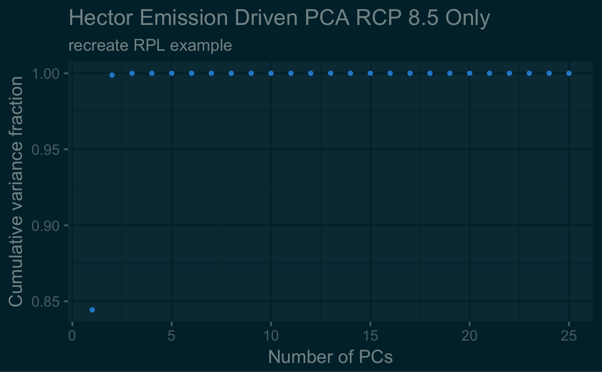

```r
plot_fvar_temp_rcp85 <- plot_frac(fvar_temp_rcp85, title = 'Hector Emission Driven PCA RCP 8.5 Only') +
    ggplot2::labs(subtitle = 'recreate RPL example')
plot_fvar_temp_rcp85
```

What do the first 3 pcs look like? (I only use the first 250 results and I subset the time series so that it only includes results from every 10 years)

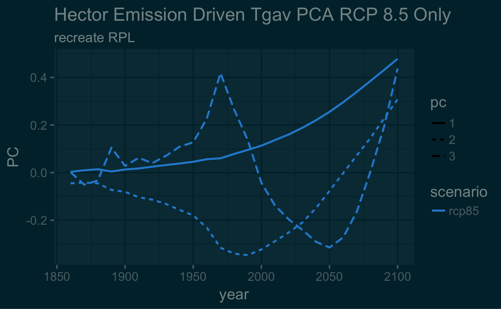

```r
plot_pcs(pca_temp_rcp85, 1:3, title = 'Hector Emission Driven Tgav PCA RCP 8.5 Only')  ->
    plot_pc_rcp85;
plot_pc_rcp85 +
    ggplot2::labs(subtitle = 'recreate RPL')
```

**Conclusion:** Awesome it looks like the exploratory one!

## A. Increase the number of years

What happens when we add more years to the PCA? So we still only have 250 obs.

**Expectation:** I think that the variance should still look the same and that the PCs will be a little smoother.

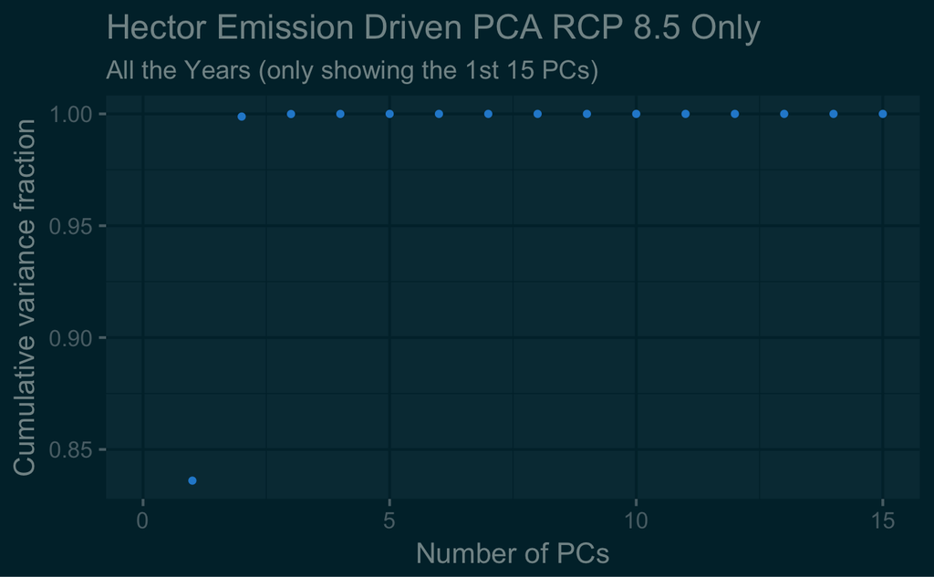

```r
pca_temp_rcp85_A <- prcomp(temp_rcp85_results[1:250, ], center = TRUE, scale. = FALSE)
fvar_temp_rcp85_A <- calc_variance(pca_temp_rcp85_A)
plot_frac(fvar_temp_rcp85_A, title = 'Hector Emission Driven PCA RCP 8.5 Only') +
    labs(subtitle = 'All the Years (only showing the 1st 15 PCs)') +
    coord_cartesian(xlim = c(0, 15))->
    plot_fvar_temp_rcp85_A; plot_fvar_temp_rcp85_A
```

How does the fraction of the variance captured by the PCs change?

```r
tibble("all the years" = head(fvar_temp_rcp85_A),
       "recreate" = head(fvar_temp_rcp85)) %>%
    mutate(diff = `all the years` - `recreate`) %>%
    knitr::kable()
```

| all the years | recreate | diff |
| --- | --- | --- |
| 0.8360656 | 0.8443907 | -0.0083252 |
| 0.9987978 | 0.9988051 | -0.0000073 |
| 0.9999394 | 0.9999465 | -0.0000071 |
| 0.9999836 | 0.9999855 | -0.0000019 |
| 0.9999961 | 0.9999972 | -0.0000010 |
| 0.9999986 | 0.9999988 | -0.0000002 |

Hmm the amount of variance explained by the PCs are very similar.

What do the first 3 PCs look like? Do they change?

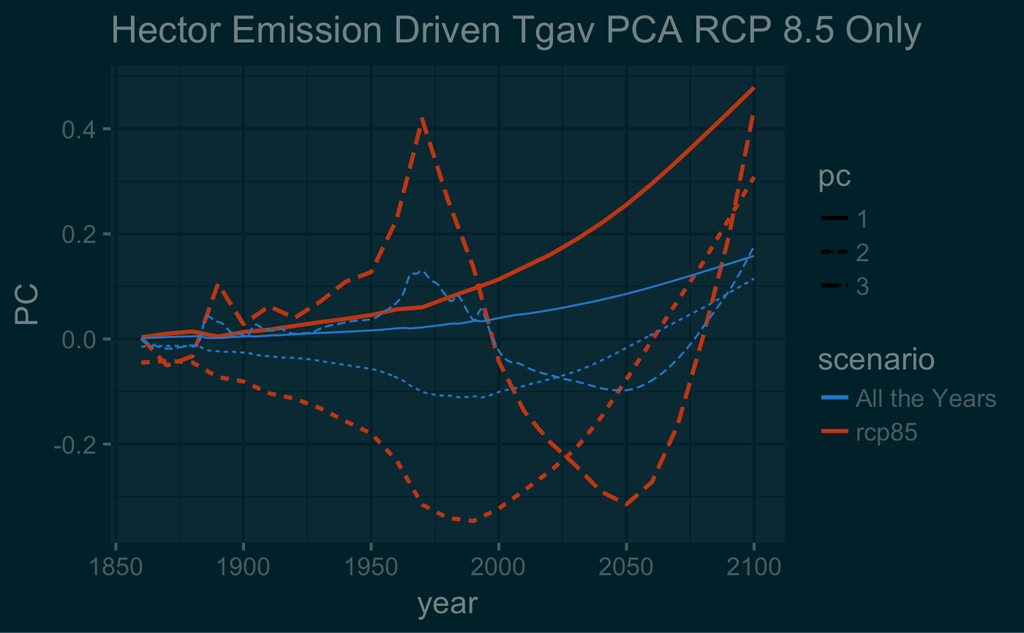

```r
plot_pcs(pca_temp_rcp85_A, 1:3, title = 'Hector Emission Driven Tgav PCA RCP 8.5 Only') +
    labs(subtitle = 'All the Years') ->
    plot_pc_rcp85_A
plot_pc_rcp85 +
    geom_line(data = plot_pc_rcp85_A$data,
              aes(year, value, color = 'All the Years', linetype = pc))
```